# Practical Machine Learning Course Project

Greg Doherty

September 20th, 2014

# Using Biometric Data To Determine “Goodness” of Exercise

This project uses the data set of biometrics from the paper cited below to create a prediction model that provides feedback on whether an exercise has been done in a proper way.

Citation: Velloso, E.; Bulling, A.; Gellersen, H.; Ugulino, W.; Fuks, H. Qualitative Activity Recognition of Weight Lifting Exercises. Proceedings of 4th International Conference in Cooperation with SIGCHI (Augmented Human ’13) . Stuttgart, Germany: ACM SIGCHI, 2013. http://groupware.les.inf.puc-rio.br/public/papers/2013.Velloso.QAR-WLE.pdf

# Initialization & Data Load

For initialization we load the caret library and the doMC library to make use of caret’s parallel mode. Will try a random forest and a support vector machine to compare and choose the best, so load the randomForest and kernlab libraries, and e1071 for its utility functions. caret would load these automatically but I wanted to keep my subsequent output cleaner below.

Using the doMC library, the number of cores to use for parallel processing is set to 4. caret by default makes use of parallel functionality if it is provided. This helps reduce elapsed time to build models.

The training and test data sets are loaded, and read.csv() is allowed to convert appropriate values to factors.

```r
library(caret)
library(doMC)
library(randomForest)
library(kernlab)
library(e1071)

registerDoMC(cores = 4)

# load data sets, converting non-numerics to factors
training <- read.csv("pml-training.csv",as.is=F)
test <- read.csv("pml-testing.csv",as.is=F)
```

# Data Evaluation, Cleaning & Predictor Selection

The data set has 159 attributes, and 19622 examples. The last attribute, *classe*, provides the correct result for each example.

Looking over the data set, there is a lot of sparseness and NA’s, so a little work needs to be done on picking good predictors to build a model with (feature selection).

## Selecting by rationale

Looking at the first few columns:

```r
str(training,list.len=5)
```

```
## 'data.frame':    19622 obs. of  160 variables:
##  $ X                       : int  1 2 3 4 5 6 7 8 9 10 ...
##  $ user_name               : Factor w/ 6 levels "adelmo","carlitos",..: 2 2 2 2 2 2 2 2 2 2 ...
##  $ raw_timestamp_part_1    : int  1323084231 1323084231 1323084231 1323084232 1323084232 1323084232 1323084232 1323084232 1323084232 1323084232 ...
##  $ raw_timestamp_part_2    : int  788290 808298 820366 120339 196328 304277 368296 440390 484323 484434 ...
##  $ cvtd_timestamp          : Factor w/ 20 levels "02/12/2011 13:32",..: 9 9 9 9 9 9 9 9 9 9 ...
##   [list output truncated]
```

It is reasonable to assume that record sequence number N and user_name will not contribute. The timestamps and converted dates could be used if creating a time series predictor window set were going to be used, but it is not necessary. Preliminary analysis found great models without having to use time sequence as a factor, except I do leave num_window and factor new_window as potential proxies for sequence/time, though new_window is removed by the skewness step below.

```r
removeCols <- c( 1:5 )           # remove N, user_name, timestamp(s), converted date
```

## Selecting by decent percentage of values != NA

Columns that are more than half NA are not very useful for prediction.

```r
NA_threshold <- 0.50
nTrain <- nrow(training)

i <- 1
while(i < ncol(training)) {
  nNA <- sum(is.na(training[,i]))
  if((nNA/nTrain) >= NA_threshold) {
     removeCols <- c(removeCols, i)
  }
  i <- i + 1
}

training <- training[,-removeCols]
test <- test[,-removeCols]
```

## Selecting by reasonable skewness

Columns that have extremely high skew are also not very useful for prediction.

```r
i <- 1
removeCols <- c( )
while(i < ncol(training)) {
  skew <- abs(skewness(as.numeric(training[,i]),na.rm=T))
  if(skew > 6) {
     removeCols <- c(removeCols, i)
  }
  i <- i + 1
}

training <- training[,-removeCols]
test <- test[,-removeCols]
```

## These Are The Attributes Selected As Predictors

```r
str(training)
```

```
## 'data.frame':    19622 obs. of  49 variables:
##  $ num_window          : int  11 11 11 12 12 12 12 12 12 12 ...
##  $ roll_belt           : num  1.41 1.41 1.42 1.48 1.48 1.45 1.42 1.42 1.43 1.45 ...
##  $ pitch_belt          : num  8.07 8.07 8.07 8.05 8.07 8.06 8.09 8.13 8.16 8.17 ...
##  $ yaw_belt            : num  -94.4 -94.4 -94.4 -94.4 -94.4 -94.4 -94.4 -94.4 -94.4 -94.4 ...
##  $ total_accel_belt    : int  3 3 3 3 3 3 3 3 3 3 ...
##  $ gyros_belt_x        : num  0 0.02 0 0.02 0.02 0.02 0.02 0.02 0.02 0.03 ...
##  $ gyros_belt_y        : num  0 0 0 0 0.02 0 0 0 0 0 ...
##  $ gyros_belt_z        : num  -0.02 -0.02 -0.02 -0.03 -0.02 -0.02 -0.02 -0.02 -0.02 0 ...
##  $ accel_belt_x        : int  -21 -22 -20 -22 -21 -21 -22 -22 -20 -21 ...
##  $ accel_belt_y        : int  4 4 5 3 2 4 3 4 2 4 ...
##  $ accel_belt_z        : int  22 22 23 21 24 21 21 21 24 22 ...
##  $ magnet_belt_x       : int  -3 -7 -2 -6 -6 0 -4 -2 1 -3 ...
##  $ magnet_belt_y       : int  599 608 600 604 600 603 599 603 602 609 ...
##  $ magnet_belt_z       : int  -313 -311 -305 -310 -302 -312 -311 -313 -312 -308 ...
```

[output cut: 35 more lines]

# Create Training and Cross-Validation data sets

Set aside 25% of the training data for cross-validation.

```r
inTrain <- createDataPartition(y=training$classe, p=0.75, list=FALSE)

train <- training[inTrain,]
crossval <- training[-inTrain,]
```

# Train Two Kinds of Models

Model/method selection in caret is a data mining project in and of itself since there are **so many** methods supported. I picked two that I knew from the literature were very good in general, random forests and support vector machines. For the support vector machine I selected a radial basis function as the kernel trick.

For development purposes the code below supports saving trained models and restoring from a file, if the file exists. This makes iterating during development possible as the models take over an hour to train.

(For the record, I also tried neural nets, but found them slow to train, limited by number of hidden nodes (roughly < 20) and I could not figure out how to pass down the ‘size’ parameter properly. The accuracy for the neural net I was able to train was 43%, so I eliminated neural nets from final use in this project.)

```r
# load saved models if they exist, otherwise, we have to train them.  remove file for final run.

if(file.exists("mymodels.sav")) {
  load("mymodels.sav")
} else {
  fitControl <- trainControl(method="repeatedcv",repeats=3)

  RFmodelFit <- train(classe ~ .,data=train,method="rf",trControl=fitControl)

  SVMmodelFit <- train(classe ~ .,data=train,method="svmRadial",trControl = fitControl)

  # save these models to disk as they take a lot of time to train
  save(list = c("RFmodelFit","SVMmodelFit"),file="mymodels.sav")
}
```

# Evaluate And Compare Models

Now evaluate models using the cross-validation data set.

This allows out of sample error to be estimated. See the 95% confidence interval in the confusion matrix for each model.

To choose best goodness of fit use Kappa metric.

## Random Forest Model Summary

```r
RFmodelFit
```

```
## Random Forest
##
## 14718 samples
##    48 predictor
##     5 classes: 'A', 'B', 'C', 'D', 'E'
##
## No pre-processing
## Resampling: Cross-Validated (10 fold, repeated 3 times)
##
## Summary of sample sizes: 13246, 13246, 13247, 13245, 13247, 13248, ...
##
## Resampling results across tuning parameters:
##
##   mtry  Accuracy  Kappa  Accuracy SD  Kappa SD
##    2    1         1      0.002        0.003
##   25    1         1      0.001        0.002
##   48    1         1      0.002        0.002
##
## Accuracy was used to select the optimal model using  the largest value.
## The final value used for the model was mtry = 25.
```

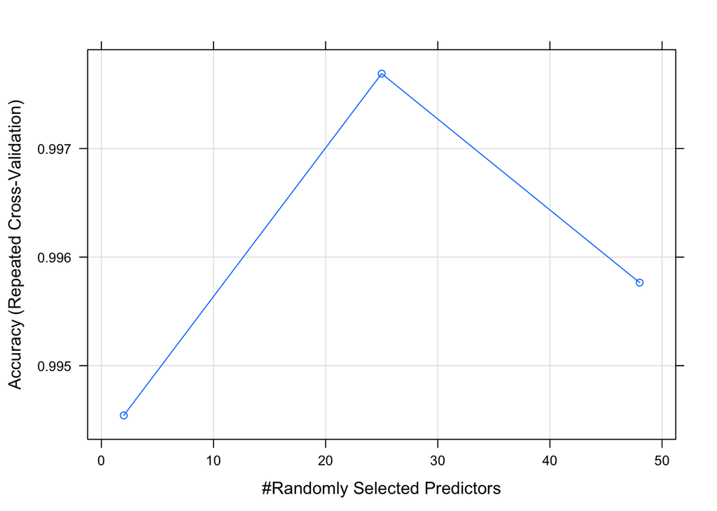

```r
plot(RFmodelFit)
```

```r
RFpred <- predict(RFmodelFit,newdata=crossval)
RFcv <- confusionMatrix(RFpred,crossval$classe)
RFcv
```

```
## Confusion Matrix and Statistics
##
##           Reference
## Prediction    A    B    C    D    E
##          A 1394    0    0    0    0
##          B    0  948    0    0    0
##          C    0    1  855    3    0
##          D    0    0    0  801    1
##          E    1    0    0    0  900
##
## Overall Statistics
##
##                Accuracy : 0.999
##                  95% CI : (0.997, 1)
##     No Information Rate : 0.284
##     P-Value [Acc > NIR] : <2e-16
##
##                   Kappa : 0.998
##  Mcnemar's Test P-Value : NA
##
## Statistics by Class:
##
##                      Class: A Class: B Class: C Class: D Class: E
## Sensitivity             0.999    0.999    1.000    0.996    0.999
## Specificity             1.000    1.000    0.999    1.000    1.000
## Pos Pred Value          1.000    1.000    0.995    0.999    0.999
## Neg Pred Value          1.000    1.000    1.000    0.999    1.000
## Prevalence              0.284    0.194    0.174    0.164    0.184
## Detection Rate          0.284    0.193    0.174    0.163    0.184
## Detection Prevalence    0.284    0.193    0.175    0.164    0.184
## Balanced Accuracy       1.000    0.999    1.000    0.998    0.999
```

## Support Vector Machine Model Summary

```r
SVMmodelFit
```

```
## Support Vector Machines with Radial Basis Function Kernel
##
## 14718 samples
##    48 predictor
##     5 classes: 'A', 'B', 'C', 'D', 'E'
##
## No pre-processing
## Resampling: Cross-Validated (10 fold, repeated 3 times)
##
## Summary of sample sizes: 13247, 13245, 13245, 13246, 13246, 13245, ...
##
## Resampling results across tuning parameters:
##
##   C    Accuracy  Kappa  Accuracy SD  Kappa SD
##   0.2  0.9       0.8    0.012        0.01
##   0.5  0.9       0.9    0.010        0.01
##   1.0  0.9       0.9    0.009        0.01
##
## Tuning parameter 'sigma' was held constant at a value of 0.01408
## Accuracy was used to select the optimal model using  the largest value.
## The final values used for the model were sigma = 0.01408 and C = 1.
```

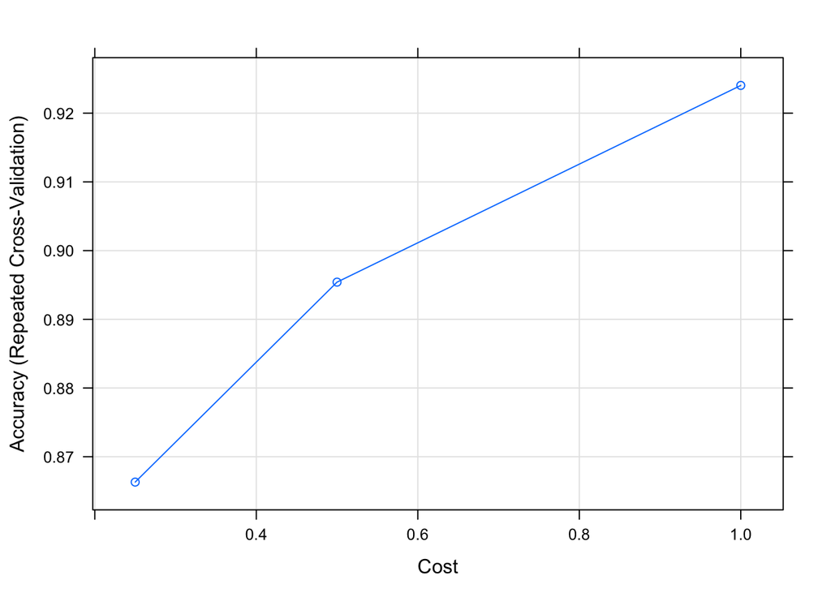

```r
plot(SVMmodelFit)
```

```r
SVMpred <- predict(SVMmodelFit,newdata=crossval)
SVMcv <- confusionMatrix(SVMpred,crossval$classe)
SVMcv
```

```
## Confusion Matrix and Statistics
##
##           Reference
## Prediction    A    B    C    D    E
##          A 1360   59    3    2    2
##          B   17  842   47    6    3
##          C   12   35  786   83   23
##          D    5    7   16  713   34
##          E    1    6    3    0  839
##
## Overall Statistics
##
##                Accuracy : 0.926
##                  95% CI : (0.918, 0.933)
##     No Information Rate : 0.284
##     P-Value [Acc > NIR] : <2e-16
##
##                   Kappa : 0.906
##  Mcnemar's Test P-Value : <2e-16
##
## Statistics by Class:
##
##                      Class: A Class: B Class: C Class: D Class: E
## Sensitivity             0.975    0.887    0.919    0.887    0.931
## Specificity             0.981    0.982    0.962    0.985    0.998
## Pos Pred Value          0.954    0.920    0.837    0.920    0.988
## Neg Pred Value          0.990    0.973    0.983    0.978    0.985
## Prevalence              0.284    0.194    0.174    0.164    0.184
## Detection Rate          0.277    0.172    0.160    0.145    0.171
## Detection Prevalence    0.291    0.187    0.191    0.158    0.173
## Balanced Accuracy       0.978    0.934    0.941    0.936    0.964
```

## Use the Kappa value to select the best model to make final predictions with

```r
#cv$overall[2] is the Kappa value for the model from the confusion matrix.  Pick the best model based on Kappa.

if(RFcv$overall[2] > SVMcv$overall[2]) {
  bestModel <- RFmodelFit
  best <- "random forest"
} else {
  bestModel <- SVMmodelFit
  best <- "support vector machine"
}
```

The best model was the random forest model.

# Make The Final Predictions using the test data set

```r
pred <- predict(bestModel,test)
```

The final predictions are: B, A, B, A, A, E, D, B, A, A, B, C, B, A, E, E, A, B, B, B

Write the predictions to separate files, per instructions, to submit for grading

```r
# write best predictions to files for submission
pml_write_files = function(x){
  n = length(x)
  for(i in 1:n){
    filename = paste0("problem_id_",i,".txt")
    write.table(x[i],file=filename,quote=FALSE,row.names=FALSE,col.names=FALSE)
  }
}

pml_write_files(pred)
```